# FinalProject

Least Safe Counties to Live in California

Ritika Sabharwal

INTRODUCTION

In the past few years, California has experienced brutal wildfires that have destroyed numerous homes and led to poor air quality. Global warming has led to an increase in temperatures, drought conditions, and dry vegetation. This leads to dryness that causes fires in hills and spreads quite far. In the past, these wildfires have destroyed forest ecosystems, homes, and created public health crises. Having lived in California, I have witnessed orange skies due to ashes in the air. Even before COVID, people would wear masks to school due to the polluted air. As a diverse state, there is also a lot of crime in California. Riots, protests, robbery, and shootings are quite common. When buying a house in California, one must consider the crime rate of the area and how prone it is to wildfires. In this tutorial, we will examine trends of wildfire and crime rates in all counties in California, and attempt to discover the least safe counties to live in California to avoid troubles for people in the future.

DATA COLLECTION

We will begin by scraping this data. Since this dataset is from Kaggle, I uploaded the zipfile to a public Git repository, which can be accessed through https://github.com/ritika621/wildfires_data/tree/1bf8cebfd5e7c2775c00fb71e5f76c7fdbbbc102.

Now, we can read the csv into pandas and create a pandas dataframe from the data.

```python
import pandas as pd
import numpy as np
from matplotlib import pyplot as plt
import numpy as np

#Reading data from csv file into pandas dataframe.
wildfire_df = pd.read_csv("California_Fire_Incidents.csv")
```

Now that we have collected data about wildfires, we will collect data about crime in California in the same way. We will be scraping data from the Crimes and Clearances dataset reported as part of the Federal Bureau of Investigation's, Uniform Crime Reporting Program. The dataset includes statistcal data about offenses, including criminal homicide, rape, robbery, aggravated assault, burglary, larceny-theft, motor vehicle theft, and arson. This dataset contains data from 1985 - 2020. This can be accessed https://github.com/ritika621/datasets/blob/main/Crimes_and_Clearances_with_Arson-1985-2020%20(2).csv.

```python
#Reading data from csv file into pandas dataframe.
crimes_df = pd.read_csv("Crimes_and_Clearances_with_Arson-1985-2020.csv")
crimes_df.head()
```

|  | Year | County | NCICCode | Violent_sum | Homicide_sum | ForRape_sum | Robbery_sum | AggAssault_sum | Property_sum | Burglary_sum | ... | MVLARnao_sum | MVPLARnao_sum | BILARnao_sum | FBLARnao_sum | COMLARnao_sum | AOLARnao_sum | LT400nao_sum | LT200400nao_sum | LT50200nao_sum | LT50nao_sum |
| --- | --- | --- | --- | --- | --- | --- | --- | --- | --- | --- | --- | --- | --- | --- | --- | --- | --- | --- | --- | --- | --- |
| 0 | 1985 | Alameda County | Alameda Co. Sheriff's Department | 427 | 3 | 27 | 166 | 231 | 3964 | 1483 | ... | 930 | 109 | 205 | 44 | 11 | 475 | 753 | 437 | 440 | 498 |
| 1 | 1985 | Alameda County | Alameda | 405 | 7 | 15 | 220 | 163 | 4486 | 989 | ... | 538 | 673 | 516 | 183 | 53 | 559 | 540 | 622 | 916 | 1159 |
| 2 | 1985 | Alameda County | Albany | 101 | 1 | 4 | 58 | 38 | 634 | 161 | ... | 147 | 62 | 39 | 46 | 17 | 37 | 84 | 68 | 128 | 138 |
| 3 | 1985 | Alameda County | Berkeley | 1164 | 11 | 43 | 660 | 450 | 12035 | 2930 | ... | 3153 | 508 | 611 | 1877 | 18 | 496 | 533 | 636 | 2793 | 4274 |
| 4 | 1985 | Alameda County | Emeryville | 146 | 0 | 5 | 82 | 59 | 971 | 205 | ... | 207 | 153 | 16 | 85 | 24 | 169 | 217 | 122 | 161 | 164 |

5 rows × 69 columns

Now that we have finished collecting the necessary data annd storing them in pandas dataframes, we will move on to the next process of the data science lifecycle.

DATA MANAGEMENT

In the data management process of the lifecycle, we are going to clean the data so that we can use it for our specific purpose. Data can be messy when we first collect it, and therefore it is important to manipulate data so that it is more organized and easier to analyze. This process is also known as tidying data or data wrangling.

For the wildfires dataset, we are only interested in data from the columns Name, ArchiveYear, AcresBurned, Counties, MajorIncident, Latitude, and Longitude. Since that leaves 33 columns to drop from the dataframe, it will be easier to reassign wildfire_df to be the dataframe with just these columns. In addition, we will drop all missing values from the dataset and reindex the dataset, as we cannot work with empty values for our analysis.

```python
wildfire_df = wildfire_df[['Name',  'ArchiveYear', 'AcresBurned','Counties', 'MajorIncident', 'Latitude', 'Longitude']]
wildfire_df.dropna(inplace=True) #DROP ALL THE ROWS WITH NAN
wildfire_df.index = range(len(wildfire_df)) #RE-INDEX THE DF
```

```python
wildfire_df.head()
```

|  | Name | ArchiveYear | AcresBurned | Counties | MajorIncident | Latitude | Longitude |
| --- | --- | --- | --- | --- | --- | --- | --- |
| 0 | Rim Fire | 2013 | 257314.0 | Tuolumne | False | 37.857000 | -120.086000 |
| 1 | Powerhouse Fire | 2013 | 30274.0 | Los Angeles | False | 34.585595 | -118.423176 |
| 2 | Mountain Fire | 2013 | 27531.0 | Riverside | False | 33.709500 | -116.728850 |
| 3 | American Fire | 2013 | 27440.0 | Placer | False | 39.120000 | -120.650000 |
| 4 | Springs Fire | 2013 | 24251.0 | Ventura | True | 0.000000 | 0.000000 |

For the crimes and clearances dataset, we are only interested in looking at the data for the crimes from every year and county. Therefore, we will only need the columns Year, County, Violent_sum, Homicide_sum, ForRape_sum, Robbery_sum, AggAssault_sum, Property_sum, Burglary_sum, VehicleTheft_sum, and LTtotal_sum. We will also drop all missing values from the dataset and reindex the dataset.

```python
crimes_df = crimes_df[['Year', 'County', 'Violent_sum', 'Homicide_sum', 'ForRape_sum', 'Robbery_sum', 'AggAssault_sum', 'Property_sum', 'Burglary_sum', 'VehicleTheft_sum', 'LTtotal_sum']]
```

```python
crimes_df.dropna(inplace=True) #DROP ALL THE ROWS WITH NAN
crimes_df.index = range(len(crimes_df)) #RE-INDEX THE DF
crimes_df.head()
```

|  | Year | County | Violent_sum | Homicide_sum | ForRape_sum | Robbery_sum | AggAssault_sum | Property_sum | Burglary_sum | VehicleTheft_sum | LTtotal_sum |
| --- | --- | --- | --- | --- | --- | --- | --- | --- | --- | --- | --- |
| 0 | 1985 | Alameda County | 427 | 3 | 27 | 166 | 231 | 3964 | 1483 | 353 | 2128 |
| 1 | 1985 | Alameda County | 405 | 7 | 15 | 220 | 163 | 4486 | 989 | 260 | 3237 |
| 2 | 1985 | Alameda County | 101 | 1 | 4 | 58 | 38 | 634 | 161 | 55 | 418 |
| 3 | 1985 | Alameda County | 1164 | 11 | 43 | 660 | 450 | 12035 | 2930 | 869 | 8236 |
| 4 | 1985 | Alameda County | 146 | 0 | 5 | 82 | 59 | 971 | 205 | 102 | 664 |

```python
crimes_df = crimes_df.groupby(['County'], as_index=False)['Violent_sum', 'Homicide_sum', 'ForRape_sum', 'Robbery_sum', 'AggAssault_sum', 'Property_sum', 'Burglary_sum', 'VehicleTheft_sum', 'LTtotal_sum'].sum()
```

```python
crimes_df.head()
```

|  | County | Violent_sum | Homicide_sum | ForRape_sum | Robbery_sum | AggAssault_sum | Property_sum | Burglary_sum | VehicleTheft_sum | LTtotal_sum |
| --- | --- | --- | --- | --- | --- | --- | --- | --- | --- | --- |
| 0 | Alameda County | 420504 | 5095 | 21659 | 189014 | 204736 | 2570863 | 502448 | 459351 | 1609064 |
| 1 | Alpine County | 382 | 4 | 36 | 2 | 340 | 3764 | 609 | 72 | 3083 |
| 2 | Amador County | 3530 | 29 | 369 | 238 | 2894 | 27689 | 8902 | 1937 | 16850 |
| 3 | Butte County | 28210 | 310 | 3369 | 4979 | 19552 | 266251 | 74292 | 29513 | 162446 |
| 4 | Calaveras County | 5133 | 98 | 503 | 331 | 4201 | 35045 | 13445 | 3206 | 18394 |

EXPLORATORY DATA ANALYSIS

In the Exploratory Data Analysis stage of the data science lifecycle, we will plot various sections of our data to look for trends. Here, we will be attempting to find correlations between data and better visualize our findings. There are several ways to do this including graphs, maps, violin plots etc.

First, we will be looking at all the major fire incidents and plot the total acres burned for every county with a major fire incident in a line graph. We will select all rows with true values for major incident and then group the data by the counties and year

```python
major_fires_df = wildfire_df.loc[wildfire_df['MajorIncident'] == True]
major_fires_df.head()
```

|  | Name | ArchiveYear | AcresBurned | Counties | MajorIncident | Latitude | Longitude |
| --- | --- | --- | --- | --- | --- | --- | --- |
| 4 | Springs Fire | 2013 | 24251.0 | Ventura | True | 0.000000 | 0.000000 |
| 6 | Silver Fire | 2013 | 20292.0 | Riverside | True | 33.861570 | -116.904270 |
| 9 | Deer Fire | 2013 | 11429.0 | Tehama | True | 40.042630 | -121.853970 |
| 10 | Clover Fire | 2013 | 8073.0 | Shasta | True | 40.498332 | -122.535496 |
| 11 | Chariot Fire | 2013 | 7055.0 | San Diego | True | 32.954350 | -116.473810 |

```python
major_fires_df = major_fires_df.groupby(['Counties', 'ArchiveYear'], as_index=False)['AcresBurned'].sum()
major_fires_df.head()
```

|  | Counties | ArchiveYear | AcresBurned |
| --- | --- | --- | --- |
| 0 | Alameda | 2015 | 2700.0 |
| 1 | Alameda | 2018 | 640.0 |
| 2 | Amador | 2014 | 4240.0 |
| 3 | Amador | 2015 | 355.0 |
| 4 | Amador | 2016 | 300.0 |

Now, we have a dataframe with counties having the most major fires called major_fires_df.

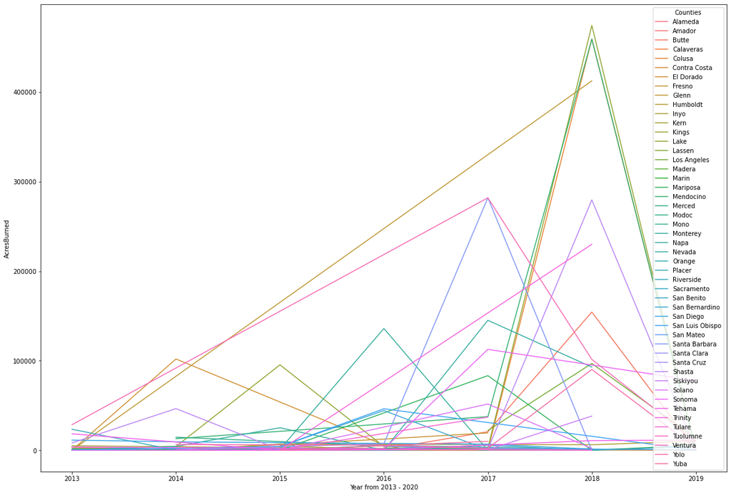

```python
import seaborn as sns
plt.figure(figsize = (20, 14))
sns.lineplot(data = major_fires_df, x='ArchiveYear', y = 'AcresBurned', hue='Counties')
plt.ylabel("AcresBurned")
plt.xlabel("Year from 2013 - 2020")
```

```
No artists with labels found to put in legend.  Note that artists whose label start with an underscore are ignored when legend() is called with no argument.
```

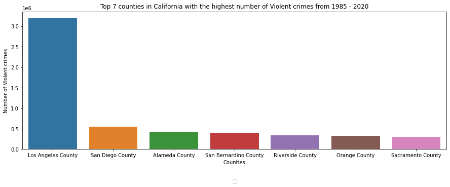

```
No artists with labels found to put in legend.  Note that artists whose label start with an underscore are ignored when legend() is called with no argument.
```

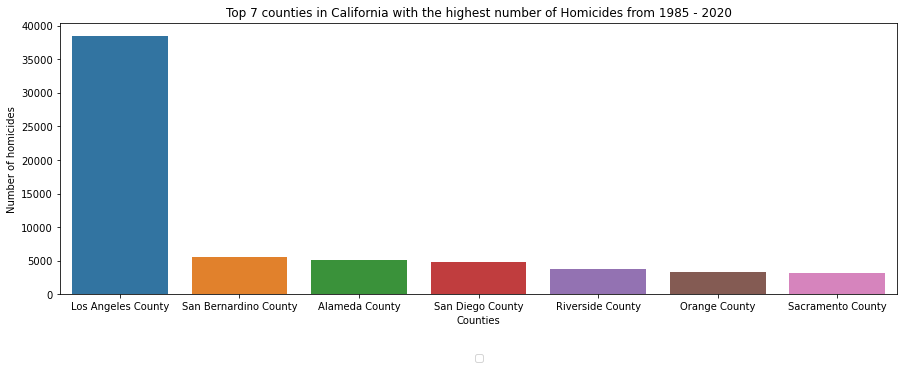

```
No artists with labels found to put in legend.  Note that artists whose label start with an underscore are ignored when legend() is called with no argument.
```

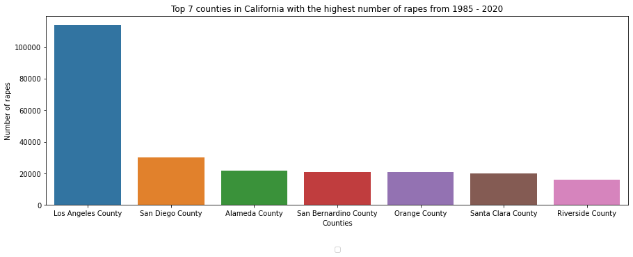

```
No artists with labels found to put in legend.  Note that artists whose label start with an underscore are ignored when legend() is called with no argument.
```

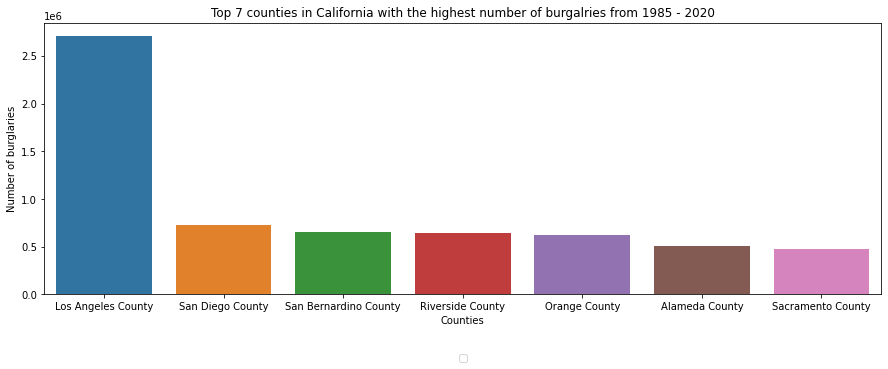

```
No artists with labels found to put in legend.  Note that artists whose label start with an underscore are ignored when legend() is called with no argument.
```

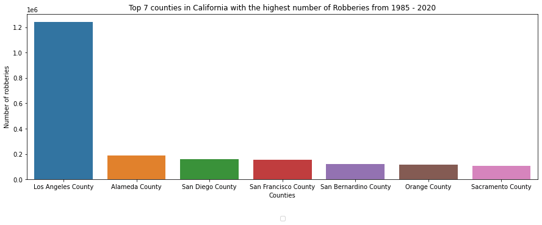

```
No artists with labels found to put in legend.  Note that artists whose label start with an underscore are ignored when legend() is called with no argument.
```

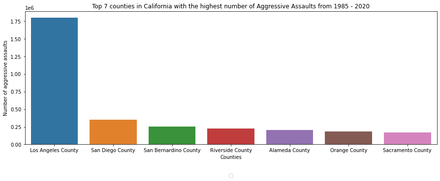

```python
violent_df = crimes_df.drop(columns = ['Homicide_sum', 'ForRape_sum', 'Robbery_sum', 'AggAssault_sum', 'Property_sum', 'Burglary_sum', 'VehicleTheft_sum', 'LTtotal_sum'])
violent_df = violent_df.sort_values(by='Violent_sum', ascending=False)
violent_df = violent_df.iloc[:7,:]

homicide_df = crimes_df.drop(columns = ['Violent_sum', 'ForRape_sum', 'Robbery_sum', 'AggAssault_sum', 'Property_sum', 'Burglary_sum', 'VehicleTheft_sum', 'LTtotal_sum'])
homicide_df = homicide_df.sort_values(by='Homicide_sum', ascending=False)
homicide_df = homicide_df.iloc[:7,:]

rape_df = crimes_df.drop(columns =    ['Homicide_sum', 'Violent_sum', 'Robbery_sum', 'AggAssault_sum', 'Property_sum', 'Burglary_sum', 'VehicleTheft_sum', 'LTtotal_sum'])
rape_df = rape_df.sort_values(by='ForRape_sum', ascending=False)
rape_df = rape_df.iloc[:7,:]

burglary_df = crimes_df.drop(columns = ['Violent_sum','Homicide_sum', 'ForRape_sum', 'Robbery_sum', 'AggAssault_sum', 'Property_sum', 'VehicleTheft_sum', 'LTtotal_sum'])
burglary_df = burglary_df.sort_values(by='Burglary_sum', ascending=False)
burglary_df = burglary_df.iloc[:7,:]

robbery_df = crimes_df.drop(columns = ['Homicide_sum', 'ForRape_sum', 'Violent_sum', 'AggAssault_sum', 'Property_sum', 'Burglary_sum', 'VehicleTheft_sum', 'LTtotal_sum'])
robbery_df = robbery_df.sort_values(by='Robbery_sum', ascending=False)
robbery_df = robbery_df.iloc[:7,:]

aggassault_df = crimes_df.drop(columns = ['Homicide_sum', 'ForRape_sum', 'Robbery_sum', 'Violent_sum', 'Property_sum', 'Burglary_sum', 'VehicleTheft_sum', 'LTtotal_sum'])
aggassault_df = aggassault_df.sort_values(by='AggAssault_sum', ascending=False)
aggassault_df = aggassault_df.iloc[:7,:]




plt.figure(figsize=(15,5))
sns.barplot(x="County", y="Violent_sum", data=violent_df)
plt.legend(loc=9, bbox_to_anchor=(0.5, -0.2), ncol=5)
plt.title('Top 7 counties in California with the highest number of Violent crimes from 1985 - 2020')
plt.xlabel('Counties')
plt.ylabel('Number of Violent crimes')
plt.show()

plt.figure(figsize=(15,5))
sns.barplot(x="County", y="Homicide_sum", data=homicide_df)
plt.legend(loc=9, bbox_to_anchor=(0.5, -0.2), ncol=5)
plt.title('Top 7 counties in California with the highest number of Homicides from 1985 - 2020')
plt.xlabel('Counties')
plt.ylabel('Number of homicides')
plt.show()

plt.figure(figsize=(15,5))
sns.barplot(x="County", y="ForRape_sum", data=rape_df)
plt.legend(loc=9, bbox_to_anchor=(0.5, -0.2), ncol=5)
plt.title('Top 7 counties in California with the highest number of rapes from 1985 - 2020')
plt.xlabel('Counties')
plt.ylabel('Number of rapes')
plt.show()

plt.figure(figsize=(15,5))
sns.barplot(x="County", y="Burglary_sum", data=burglary_df)
plt.legend(loc=9, bbox_to_anchor=(0.5, -0.2), ncol=5)
plt.title('Top 7 counties in California with the highest number of burgalries from 1985 - 2020')
plt.xlabel('Counties')
plt.ylabel('Number of burglaries')
plt.show()

plt.figure(figsize=(15,5))
sns.barplot(x="County", y="Robbery_sum", data=robbery_df)
plt.legend(loc=9, bbox_to_anchor=(0.5, -0.2), ncol=5)
plt.title('Top 7 counties in California with the highest number of Robberies from 1985 - 2020')
plt.xlabel('Counties')
plt.ylabel('Number of robberies')
plt.show()

plt.figure(figsize=(15,5))
sns.barplot(x="County", y="AggAssault_sum", data=aggassault_df)
plt.legend(loc=9, bbox_to_anchor=(0.5, -0.2), ncol=5)
plt.title('Top 7 counties in California with the highest number of Aggressive Assaults from 1985 - 2020')
plt.xlabel('Counties')
plt.ylabel('Number of aggressive assaults')
plt.show()
```

As we can see, Los Angeles county has the highest numbers for all the crimes. This suggests that Los Angeles county is most prone to crimes. In addiiton, Sacramento county and San Diego County also appear several times.

Now, we will combine wildfires and crimes, to see the top counties most prone to both of these. We will use a scatter plot and a linear regression to see analyse the results.

```python
columns_list = ['Violent_sum', 'Homicide_sum', 'ForRape_sum', 'Robbery_sum', 'AggAssault_sum', 'Property_sum', 'Burglary_sum', 'VehicleTheft_sum', 'LTtotal_sum']
total_crimes_df = crimes_df
total_crimes_df['all_crimes'] = total_crimes_df[columns_list].sum(axis=1)
total_crimes_df = total_crimes_df.drop(columns = ['Robbery_sum','Homicide_sum', 'ForRape_sum', 'Violent_sum', 'AggAssault_sum', 'Property_sum', 'Burglary_sum', 'VehicleTheft_sum', 'LTtotal_sum'])
```

```python
total_crimes_df.columns = ['Counties', 'All_Crimes']
total_crimes = total_crimes_df["Counties"].str.replace(" County","").to_numpy()
fires_df = wildfire_df.groupby(['Counties'], as_index=False)['AcresBurned'].sum()
total_crimes_df['Counties'] = total_crimes
joint_df = pd.merge(total_crimes_df, fires_df, on = ['Counties'])
```

```python
joint_df['AcresBurned'] = joint_df['AcresBurned'].astype(int)
joint_df['All_Crimes'] = joint_df['All_Crimes'].astype(int)
joint_df.head()
```

|  | Counties | All_Crimes | AcresBurned |
| --- | --- | --- | --- |
| 0 | Alameda | 5982734 | 6387 |
| 1 | Alpine | 8292 | 0 |
| 2 | Amador | 62438 | 6285 |
| 3 | Butte | 588922 | 190702 |
| 4 | Calaveras | 80356 | 2648 |

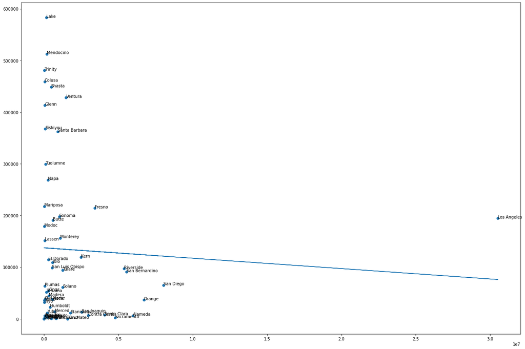

```python
import matplotlib.pyplot as plt
plt.figure(figsize = (22, 15))
plt.scatter(joint_df['All_Crimes'], joint_df['AcresBurned'])

annotations = joint_df['Counties'].to_numpy()
x = joint_df['All_Crimes'].to_numpy()
y = joint_df['AcresBurned'].to_numpy()
m, b = np.polyfit(x, y, 1)

plt.plot(x, m*x + b)

for i, label in enumerate(annotations):
    plt.annotate(label, (x[i], y[i]))
```